# Doğa Bilimlerinde R Programlamaya Giriş

## 2. Gün

- Kısım 1: Olasılık ve Olasılık Dağılımları
- Kısım 2: T-testi, güven aralığı, ve p değeri
- Kısım 3: Lineer Regresyon ve ANOVA

## Kısım 1: Olasılık ve Olasılık Dağılımları

## Temel Olasılık Kuralları

- Bir torba dolusu bilye.
- 3 renk: Kırmızı, Mavi, Yeşil.
  - \(P(K)\) : Kırmızı bilye çekme olasılığı
  - \(P(M)\) : Mavi bilye çekme olasılığı
  - \(P(Y)\) : Yeşil bilye çekme olasılığı

## Temel Olasılık Kuralları

- Torbadan kırmızı VE mavi bilye çekme olasılığı?

\(P(K \cap M) = P(K,M) = P(K) \cdot P(M)\)

- Torbadan kırmızı VEYA yeşil bilye çekme olasılığı?

\(P(K \cup Y) = P(K) + P(Y) - P(K) \cdot P(Y)\)

## Koşullu Olasılık

- Türkiye'de bir insanın boyunun 180 cm'den uzun olma olasılığı:

\[ P(B) \]

- Türkiye'de bir insanın kadın olma olasılığı:

\[ P(K) \]

- Türkiye'de bir kadının boyunun 180 cm'den uzun olma olasılığı:

\[ P(B \mid K) = \frac {P(B,K)}{P(K)} = \frac {P(B \cap K)}{P(K)} \]

## Hesaplama belirsizliği (Estimation Uncertainty)

Beypazarı'nda Mayıs ayı boyunca ağ kullanarak Küçük Akbaba (*Neophron percnopterus*) yakalıyorsunuz ve kanat uzunluğunu ölçüyorsunuz. Ölçtüğünüz her bireyin kanat uzunluğu birbirinden farklı. Bu çeşitliliğe katkıda bulunan faktörler neler?

## Hesaplama belirsizliği (Estimation Uncertainty)

Ölçtüğünüz kanat uzunlukları ile Küçük Akbaba Beypazarı populasyonunun ortalama kanat uzunluğunu hesaplamak istiyorsunuz. Sizin ortalama ölçümünüz ile populasyonun gerçek ortalamasının farklı olmasına yol açan faktörler neler?

## Hesaplama belirsizliği (Estimation Uncertainty)

- Bu belirsizliği matetimatiksel olarak ifade edebilmek için olasılık dağılımlarından yararlanıyoruz.
- \(X \sim N(\mu, \sigma^2)\)
- \(\mu\): Populasyon ortalaması
- \(\sigma^2\): Gözlem hatası (Observation error) + Süreç varyansı (Process variance)

## En basit dağılım: Bernoulli Dağılımı

- Yazı mı tura mı?
- 1 mi 0 mı?
- Tek parametre: \(p\)

## Binom(Binomial) Dağılımı

- Bernoulli'nin genelleştirilmiş hali.
- İki parametre: \(p\) ve \(N\)
- \(N=1\) olduğunda bernoulli dağılımı diyoruz.

## Binom Dağılımı

### Probability Mass Function (PMF)

\[ P(x \mid p,N) = \frac{N!}{x! \cdot (N-x)!} \cdot p^x \cdot (1-p)^{N-x} \\ N \in \mathbb{Z}^+ \\ x \in \{0,1,2,...,N\} \\ p \in [0,1] \]

## Binom Dağılımı

### R'da kullanımı

- `?rbinom` yazmayı deneyelim.
- \(N=10\) ve \(p=0.5\) olsun.

```r
rbinom(1, size = 10, prob = 0.5)
```

```
## [1] 6
```

```r
dbinom(5, 10, 0.5)
```

```
## [1] 0.2460938
```

## Binom Dağılımı

### R'da kullanımı

```r
x <- rbinom(1000, 10, 0.5)
head(x)
```

```
## [1] 5 6 4 6 8 7
```

```r
length(which(x==5))/length(x)
```

```
## [1] 0.266
```

## Binom Dağılımı

### R'da kullanımı

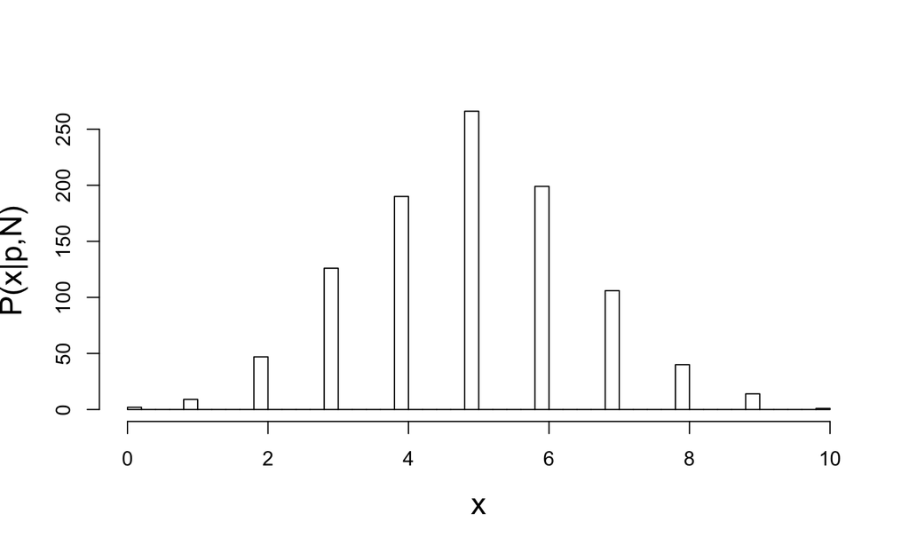

```r
hist(x, breaks = 50, ylab = "P(x|p,N)", xlab = "x", main = "", cex.lab = 1.5)
```

## Binom Dağılımı

### PMF

\[ P(x \mid p,N) = \frac{N!}{x! \cdot (N-x)!} \cdot p^x \cdot (1-p)^{N-x} \\ \sum_{x=0}^{N} P(x \mid p,N) = 1 \]

## Alıştırma 1.1

\(x_1\) ve \(x_2\) bağımsız ve binom dağılımı gösteren değişkenler ise, \(p=0.2\) ve \(N=40\) iken, \(x_1=5\) ve \(x_2=25\) olma olasılığı kaçtır?

\[ P(x_1=5 \cap x_2=25 \mid p=0.2,N=40) \]

## Poisson Dağılımı

- Tek parametre: \(\lambda\)
- \(\lambda\) hem dağılımın ortalaması hem de varyansı.
- Daha çok sayılabilen kavramların dağılımında kullanılır.
- Tür zenginliği, Populasyon büyüklüğü vb.

## Poisson Dağılımı

### PMF

\[ P(x \mid \lambda) = \frac {e^{-\lambda} \cdot \lambda^x}{x!} \\ x \in \mathbb{N} \\ \lambda >0 \\ \sum_{x=0}^{\infty} P(x \mid \lambda) = 1 \]

## Poisson Dağılımı

### R'da kullanımı

```r
x1 <- rpois(10000, lambda = 50)
x2 <- rpois(10000, lambda = 25)
x3 <- rpois(10000, lambda = 15)
```

## Poisson Dağılımı

### R'da kullanımı

```r
plot(density(x1), main = "", xlim = c(0,90), ylim = c(0,0.11), lwd  = 2,
     xlab = "x", ylab = "P(x|Lambda)", cex.lab = 1.5)
lines(density(x2), col = "red", lwd  = 2)
lines(density(x3), col = "blue", lwd  = 2)
```

## Poisson Dağılımı

### R'da kullanımı

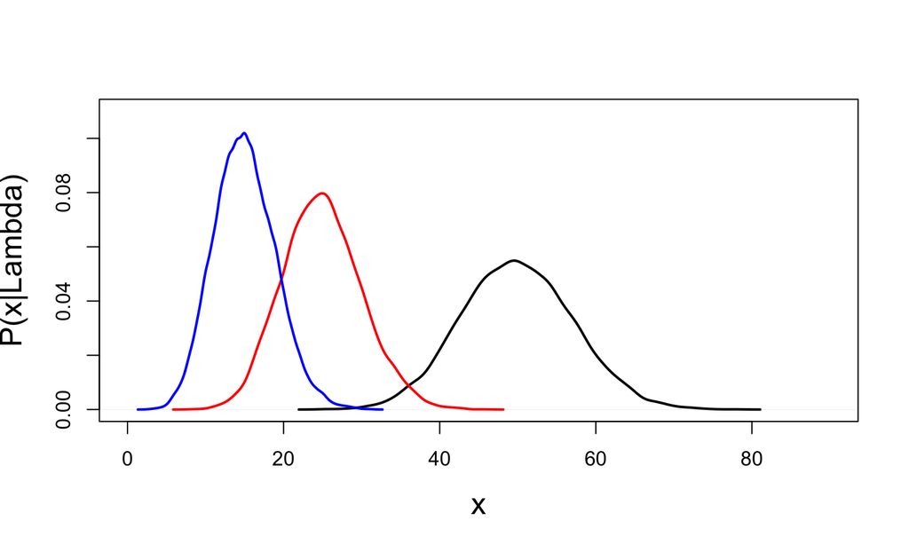

## Poisson Dağılımı

### R'da kullanımı

```r
dpois(25,lambda = 50)
```

```
## [1] 3.705786e-05
```

```r
dpois(100,lambda = 50)
```

```
## [1] 1.630319e-10
```

## Poisson Dağılımı

### R'da kullanımı

- Yüzdelik dilimler

```r
qpois(0.5,lambda = 50)
```

```
## [1] 50
```

```r
qpois(0.1,lambda = 20)
```

```
## [1] 14
```

## Poisson Dağılımı

### R'da kullanımı

- Yüzdelik dilimler

```r
ppois(50,lambda = 50)
```

```
## [1] 0.5375167
```

```r
ppois(14,lambda = 20)
```

```
## [1] 0.1048643
```

## Alıştırma 1.2

\(x\) bağımsız ve poisson dağılım gösteren bir değişken ise, \(P(x>10 \mid \lambda=15)\)?

## Normal dağılım

- En bilinen dağılım.
- Herhangi bir dağılım gösteren rastgele değişkenler sonsuz limitte normal dağılım gösterir.
- Herhangi bir dağılım gösteren rastgele değişkenlerin örneklem ortalaması normal dağılım gösterir (**Cental Limit Theorem**).
- İki parametre: \(\mu\) ve \(\sigma^2\)

## Normal dağılım

### Probablity Density Function (PDF)

\[ f(x \mid \mu, \sigma) =\frac {1}{\sqrt{2 \cdot \pi \cdot \sigma^2}} \cdot e^{\frac {(x-\mu)^2}{2 \cdot \sigma^2}} \\ x \in \mathbb{R} \\ \mu \in \mathbb{R} \\ \sigma >0 \\ \int_{-\infty}^{\infty}f(x \mid \mu,\sigma)=1 \]

## Normal dağılım

### R'da kullanımı

```r
rnorm(1, mean = 10, sd = 5)
```

```
## [1] 6.472457
```

```r
x <- rnorm(100, mean = 10, sd = 5)
head(x)
```

```
## [1]  8.301991 10.819746 18.111087 -1.730912 10.955845  7.282238
```

## Normal dağılım

### R'da kullanımı

```r
dnorm(1, mean = 0, sd = 1)
```

```
## [1] 0.2419707
```

```r
dnorm(0, mean = 0, sd = 1)
```

```
## [1] 0.3989423
```

```r
dnorm(-10, mean = 0, sd = 1)
```

```
## [1] 7.694599e-23
```

## Normal dağılım

### R'da kullanımı

- Olasılık yoğunluğu aynı olasılık kurallarına tabidir.

\[ f(x_1=10 \cap x_2=12 \mid \mu=5, \sigma=10) \]

```r
dnorm(10, mean = 5, sd = 10)*dnorm(12, mean = 5, sd = 10)
```

```
## [1] 0.001099338
```

## Normal dağılım

### R'da kullanımı

- Normal dağılım ile gerçek olasılık hesaplama.

\[ P(0<x<10 \mid \mu=5, \sigma=10) = \int_{0}^{10} f(x \mid \mu=5, \sigma=10) \]

## Normal dağılım

### R'da kullanımı

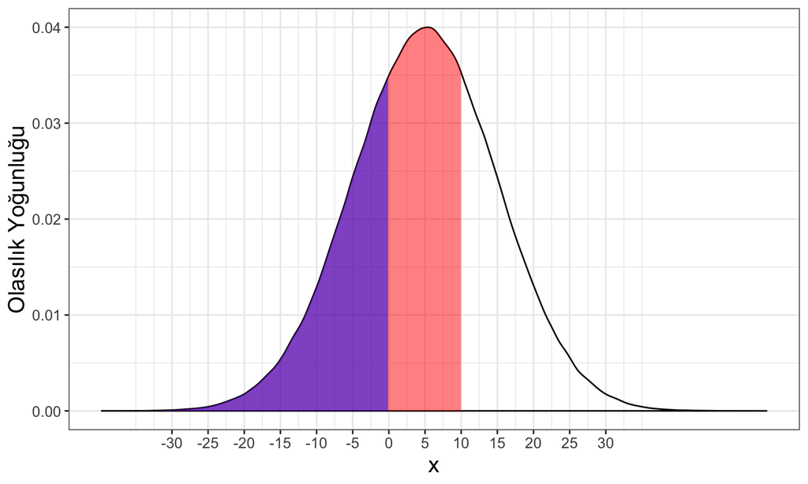

## Normal dağılım

### R'da kullanımı

```r
pnorm(10,5,10) - pnorm(0,5,10)
```

```
## [1] 0.3829249
```

## Alıştırma 1.3

Bağımsız ve Normal dağılım gösteren bir `x` değişkeninin, \(\mu=0\) ve \(\sigma=1\) iken, 2'den büyük veya -2'den küçük olma ihtimali kaçtır?

\[ P(x>2 \cup x<-2 \mid \mu=0,\sigma=1) \]

## Alıştırma 1.3

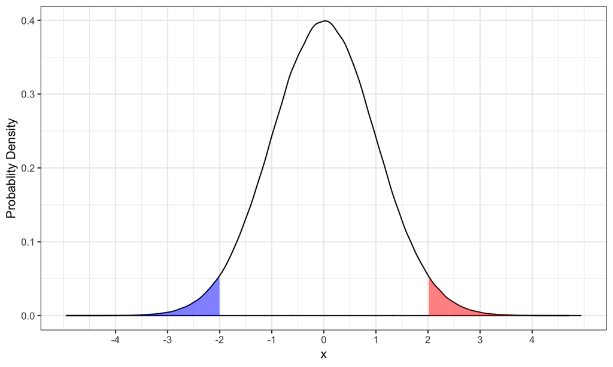

## Veri simülasyonu (kendin pişir kendin ye)

- Bu dağılımlardan yararlanarak kendi verimizi simüle edebiliriz!
- Basit bir senaryo: Kuzey Amerika'da güney ve kuzey Vaşak(Bobcat, *Lynx rufus*) populasyonlarının hem dağılım gösterdiği habitatlar hem de diyetleri biribirinden oldukça farklı. Bu farklılıklar vücut ağırlıklarından bir ayrışmaya da dönüşüyor mu? Bir grup bilim adamı bu hipotezi test etmek için iki populasyondan 10'ar vaşak yakalayıp ağırlıklarını ölçüyor.

## Veri simülasyonu (kendin pişir kendin ye)

```r
south <- rnorm(10, 8, 3)
north <- rnorm(10, 12, 3)
t.test(south, north)
```

```
##
##  Welch Two Sample t-test
##
## data:  south and north
## t = -1.6991, df = 16.808, p-value = 0.1077
## alternative hypothesis: true difference in means is not equal to 0
## 95 percent confidence interval:
##  -6.008512  0.650431
## sample estimates:
## mean of x mean of y
##  9.860611 12.539651
```

## Kısım 2: T-testi, güven aralığı, ve p-değeri

## T-testi

### Tek grup

\[ X \sim N(\mu, \sigma^2) \]

## T-testi

### Tek grup

\[ \bar{X} \sim N(\mu, \frac {\sigma^2}{n}) \]

## T-testi

### Tek grup

\[ \bar{X} - \mu \sim N(0, \frac {\sigma^2}{n}) \]

## T-testi

### Tek grup

\[ \frac {\bar{X} - \mu}{\frac {\sigma}{\sqrt{n}}} \sim N(0,1) \\ \]

## T-testi

### Tek grup

\[ \frac {\bar{X} - \mu}{\frac {s}{\sqrt{n}}} \sim t_{n-1} \]

## T-testi

### Test istatistiği

\[ T^* = \frac {\bar{X} - \mu}{\frac {s}{\sqrt{n}}} \sim t_{n-1} \]

- Hiçlik hipotezinin doğru olması koşulu ile test istatistiği bir dağılım gösterir.
- P değeri bu dağılım üzerinden hesaplanır.

## T-testi

### Hiçlik Hipotezi (Null Hypothesis)

- mesela bir hipotez: \(\mu=5\).
- Öyle ise veri \(X \sim N(5,\sigma^2)\)
- Bu durumda \(T^*=\frac{ \bar{X}-5}{\frac{s}{\sqrt{n}}} \sim t_{n-1}\)
- Bu dağılımı kullanarak bir olasılık hesaplayabilir miyiz?

## T-testi

### Hiçlik Hipotezi

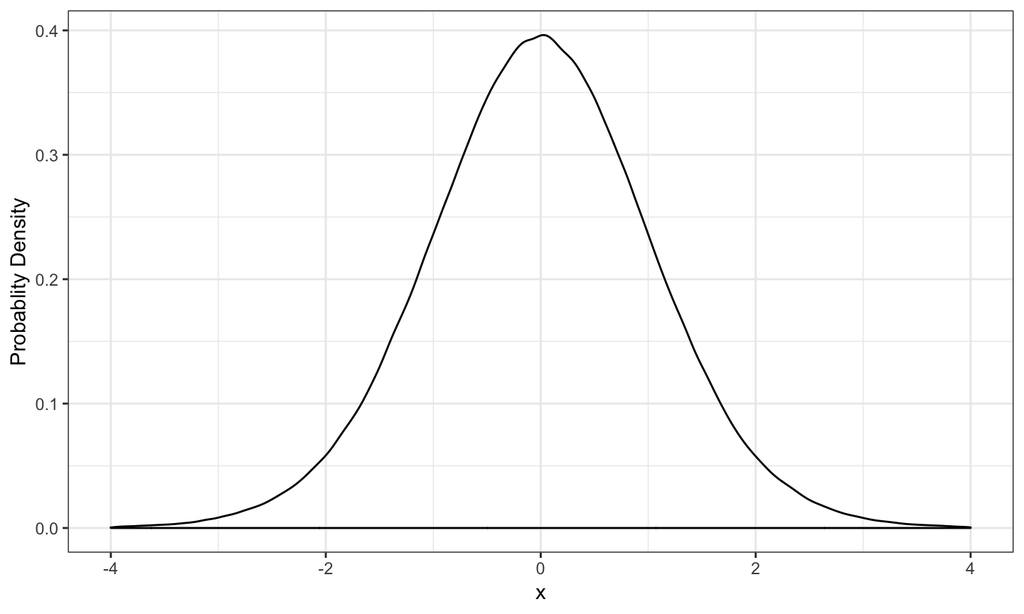

## T-testi

### T*=1.5 iken p-değeri

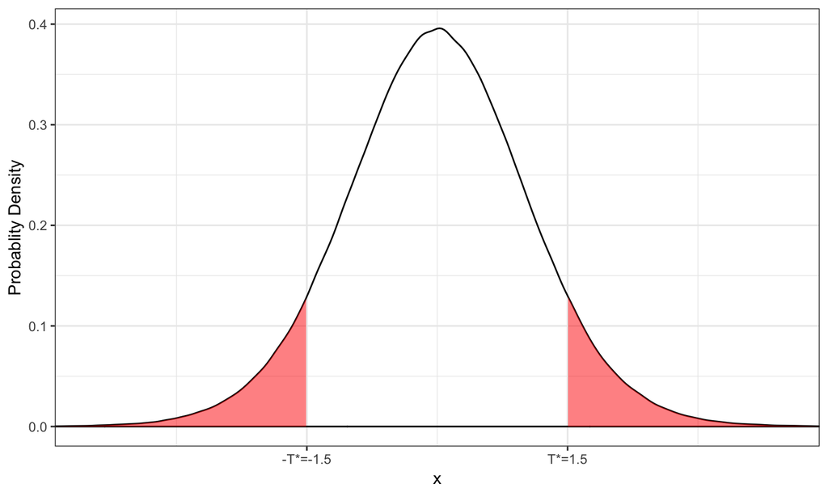

## T-testi

### p-değeri

- **p-değeri**: Hiçlik hipotezi altında elimizdeki veriden daha aşırı veri elde etme olasılığı.
- \(T\) rastgele ve bağımsız \(t_{n-1}\) dağılmı gösteren bir değişken olsun.
- \(p = P(T^*>T \mid H_0) + P(-T^*<T \mid H_0)\)

## Alıştırma 2.1

- Tek gruplu t-testi analizi yapan bir fonksiyon yazın.
- İpuçları:
  - Bu fonksiyonun iki girdisi olmalı: Bir vektör olarak örnekleminiz, ve tek bir rakam olarak hipoteziniz.
  - İki tane de çıktısı olmalı: T* istatistiği ve p değeri.
  - Bunları hesaplamak için önceki slaytlardaki formüllerden yararlanabilirsiniz.

Kuzey Amerika'daki dişi vaşak ağırlığının \(N(6.8,2^2)\) dağılım gösterdiğini varsayalım.

- Bu populasyon 20 bireylik bir örneklem oluşturun.
- Populasyonun ortalamasının 5'e eşit olup olmadığını yadığınız fonksiyon ile test edin.

## T-testi

### %95 Güven aralığı

\[ \frac{ \bar{X}-\mu}{\frac{s}{\sqrt{n}}} \sim t_{n-1} \]

## T-testi

### %95 Güven aralığı

\[ \frac{ \mu- \bar{X}}{\frac{s}{\sqrt{n}}} \sim t_{n-1} \]

## T-testi

### %95 Güven aralığı

\[ \mu - \bar{X} \sim t_{n-1} \cdot \frac{s}{\sqrt{n}} \]

## T-testi

### %95 Güven aralığı

\[ \mu \sim \bar{X} + t_{n-1} \cdot \frac{s}{\sqrt{n}} \]

## T-testi

### %95 Güven aralığı

\[ \bar{X} + t_{(n-1)[0.025]} \cdot \frac{s}{\sqrt{n}} \le \mu \le \bar{X} + t_{(n-1)[0.975]} \cdot \frac{s}{\sqrt{n}} \]

## T-testi

### %95 Güven aralığı

\[ \bar{X} - t_{(n-1)[0.975]} \cdot \frac{s}{\sqrt{n}} \le \mu \le \bar{X} + t_{(n-1)[0.975]} \cdot \frac{s}{\sqrt{n}} \]

## T-testi

### %95 Güven aralığı

\[ P \left( \bar{X} - t_{(n-1)[0.975]} \cdot \frac{s}{\sqrt{n}} \le \mu \le \bar{X} + t_{(n-1)[0.975]} \cdot \frac{s}{\sqrt{n}} \right)=1 - \alpha \]

## T-testi

### %95 Güven aralığı

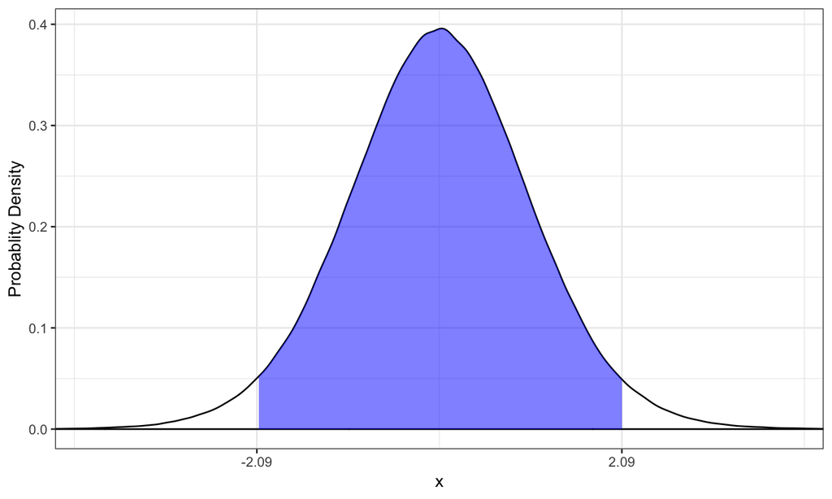

## Alıştırma 2.2

- Bir önceki Alıştırmade yazdığınız fonksiyona güven aralığı hesaplamayı ekleyin. Böylece fonskiyonunuzun 3 çıktısı olacak: T*, p-değeri, ve %95 güven aralığı.
- Sonuçlarınızı R'daki **t.test** fonksiyonu ile kıyaslayın. Yazdığınız fonksiyona benzer olarak **t.test** fonksiyonuna hipotezinizi *mu* girdisi ile belirtebilirisiniz. Yardım için **?t.test**'i kullanın.

## Güven aralığı ve p-değerinin anlamı

\(\alpha=0.05\) iken

- Örnekleme ve analiz işlemlerini 100 defa tekrar edersek ve eğer hiçlik hipotezimiz doğru ise, bu hiptezi 5 defa yanlış bir şekilde reddederiz.
- Örnekleme ve analiz işlemlerini 100 defa tekrar edersek ve eğer hiçlik hipotezimiz doğru ise, Güven aralığımız doğru parametere değerini (önceki örneklerdeki \(\mu\)) 95 defa içerecektir.

## Alıştırma 2.3

10000 defa dişi vaşak populasyonundan, \(N(6.8,2^2)\), 20'lik örneklem çekin. Her defasında bir t-testi uygulayın ve:

- p-değerinin kaç defa 0.05'ten düşük geldiğini hesaplayın. Bunu 10000'e oranlayın. Bu sonuç ile \(\alpha=0.05\)'i kıyaslayın.
- Güven aralığının kaç defa doğru parametre değerini (\(\mu=6.8\)) içerdiğini hesaplayın. Bunu 10000'e oranlayın. Bu sonuç ile \(1-\alpha=0.95\)'i kıyaslayın.

## İki grup t-testi

\[ \frac {(\bar{X_A} - \bar{X_B}) - (\mu_a-\mu_b)}{SE_{diff}} \sim t_{n_a+n_b-1} \]

## İki grup t-testi

\[ \frac {\bar{X_A} - \bar{X_B}}{SE_{diff}} \sim t_{n_a+n_b-1} \]

## İki grup t-testi

```r
south <- rnorm(10, 8, 3)
north <- rnorm(10, 12, 3)
t.test(south, north)
```

```
##
##  Welch Two Sample t-test
##
## data:  south and north
## t = -3.8841, df = 14.315, p-value = 0.00159
## alternative hypothesis: true difference in means is not equal to 0
## 95 percent confidence interval:
##  -4.424333 -1.280607
## sample estimates:
## mean of x mean of y
##  8.160869 11.013339
```

## Standart hata

- Ortalamaların dağılmının standart sapması.
- Daha genel olarak bir parametrenin dağılımının standar sapması.
- Örneklem büyüklüğü arttıkça standart hata düşer.
- Örneklem büyüklüğü arttıkça verinizin standart sapması düşebilir veya yükselebilir.

## Alıştırma 2.4

10000 defa dişi vaşak populasyonundan, \(N(6.8,2^2)\), 10'luk örneklem çekin. Her defasında örnekleminizin ortalamasını hesaplayın. Daha sonra tüm bu ortalamaların standart sapmasını hesaplayın. Aynı işlemi 50'lik ve 100'lük örneklem ile tekrar edin. Hesapladığınız standart sapmalar, ortalamanının standart hatası.

## Alıştırma 2.5

10000 defa dişi vaşak populasyonundan, \(N(6.8,2^2)\), 10'luk örneklem çekin. Her defasında örnekleminizin standart sapmasını hesaplayın. Daha sonra tüm bu standart sapmaların standart sapmasını hesaplayın. Aynı işlemi 50'lik ve 100'lük örneklem ile tekrar edin. Hesapladığınız standart sapmalar, standart sapmanın standart hatası.

## Kısım 3: Lineer Regresyon ve ANOVA

## En basit model

\[ Y \sim N(\mu, \sigma^2) \]

## Lineer regresyon

\[ Y_i \sim N(\mu_i, \sigma^2) \]

## Lineer regresyon

\[ Y_i \sim N(\mu_i, \sigma^2) \\ \mu_i = \alpha + \beta \cdot X_i \]

\[ Y_i = \alpha + \beta \cdot X_i + \epsilon_i \\ \epsilon_i \sim N(0,\sigma^2) \]

## Lineer regresyon

### Veri simulasyonu

```r
alpha <- 1
beta <- 0.5
x <- 1:20
y <- alpha + beta*x
y
```

```
##  [1]  1.5  2.0  2.5  3.0  3.5  4.0  4.5  5.0  5.5  6.0  6.5  7.0  7.5  8.0
## [15]  8.5  9.0  9.5 10.0 10.5 11.0
```

- Yanlış!!

## Lineer regresyon

### Veri simulasyonu

```r
alpha <- 1
beta <- 0.5
sigma <- 1
x <- 1:20
mu <- alpha + beta*x

y <- c()
for (i in 1:length(mu)) {
  y[i] <- rnorm(1, mu[i], sigma^2)
}
y
```

```
##  [1]  0.3599264  2.3973362  4.5348804  4.5907716  1.7488146  4.0636435
##  [7]  4.6177817  4.8232018  4.3837680  6.2043999  7.1695717  5.2711218
## [13]  8.6246081  7.3561566 10.1963398 10.6269806  9.0909586 11.3105702
## [19] 10.4193028 11.8254731
```

## Lineer regresyon

### Veri simulasyonu

```r
lm(y~x)
```

```
##
## Call:
## lm(formula = y ~ x)
##
## Coefficients:
## (Intercept)            x
##      0.8833       0.5331
```

## Lineer regresyon

### Veri simulasyonu

```r
model1 <- lm(y~x)
summary(model1)
```

```
##
## Call:
## lm(formula = y ~ x)
##
## Residuals:
##     Min      1Q  Median      3Q     Max
## -2.0093 -0.8888 -0.0035  0.8162  2.0523
##
## Coefficients:
##             Estimate Std. Error t value Pr(>|t|)
## (Intercept)  0.88330    0.53587   1.648    0.117
## x            0.53309    0.04473  11.917 5.64e-10 ***
## ---
## Signif. codes:  0 '***' 0.001 '**' 0.01 '*' 0.05 '.' 0.1 ' ' 1
##
## Residual standard error: 1.154 on 18 degrees of freedom
## Multiple R-squared:  0.8875, Adjusted R-squared:  0.8813
## F-statistic:   142 on 1 and 18 DF,  p-value: 5.642e-10
```

## Olabilirlik (likelihood) kavramı

- Düzgün(fair) bir bozuk paranız var. Bu bozuk parayı 10 defa atacaksınız. 7 defa yazı gelme ihtimali nedir?
- Bir bozuk parayı 10 defa attınız. 7 defa yazı geldi. Bu bozuk paranın düzgün(fair) olma ihtimali nedir?

## Olabilirlik (likelihood) kavramı

- \(p=0.5\). 10'dan 7 defa yazı gelme ihtimali nedir?
- 10'dan 7 defa yazı geldi. \(p=0.5\) olma ihtimali nedir?

## Azami olabilirlik hesaplaması (maximum likelihood estimation)

- 10'dan 7 defa yazı geldi. \(p=0.5\) olma ihtimali nedir? Bu olasılık direkt olarak hesaplanamaz.
- Eğer \(p=0.1\) ise 10'dan 7 defa yazı gelme ihtimali nedir? Veya eğer \(p=0.2\) ise 10'dan 7 defa yazı gelme ihtimali nedir?
- Bu şekilde pek çok farklı \(p\) denenir. Hesaplanan her ihtimale olabilirlik denir.
- Azami olabilirlik değerini veren \(p\)'nin, verinin geldiği dağılımın \(p\)'si olduğunu varsayarız.

## Azami olabilirlik hesaplaması

### Binom Dağılımı

```r
x <- rbinom(10, 1, 0.5)
# p'nin ne oldğunu bilmediğimizi varsayalım
p <- seq(0,1,0.01)
head(p)
```

```
## [1] 0.00 0.01 0.02 0.03 0.04 0.05
```

## Azami olabilirlik hesaplaması

### Binom Dağılımı

```r
db <- dbinom(x, 1, p = 0.2)
head(x)
```

```
## [1] 0 0 0 1 0 1
```

```r
head(db)
```

```
## [1] 0.8 0.8 0.8 0.2 0.8 0.2
```

```r
prod(db)
```

```
## [1] 0.0001048576
```

## Azami olabilirlik hesaplaması

### Binom Dağılımı

```r
likelihood <- c()
for (i in 1:length(p)) {
  db <- dbinom(x, 1, p = p[i])
  likelihood[i] <- prod(db)
}
head(p)
```

```
## [1] 0.00 0.01 0.02 0.03 0.04 0.05
```

```r
head(likelihood)
```

```
## [1] 0.000000e+00 9.509900e-11 2.892547e-09 2.086724e-08 8.349416e-08
## [6] 2.418065e-07
```

## Azami olabilirlik hesaplaması

### Binom Dağılımı

```r
which(likelihood==max(likelihood))
```

```
## [1] 51
```

```r
index <- which(likelihood==max(likelihood))
p[index]
```

```
## [1] 0.5
```

```r
mean(x)
```

```
## [1] 0.5
```

## Azami olabilirlik hesaplaması

### Normal Dağılım

- hesaplamak istediğimiz parametre \(\mu\), dağılımın ortalaması.

```r
x <- rnorm(25, 5, 2)
mu <- seq(-10, 10, 0.1)
stan.dv <- seq(0, 5, 0.1)
likelihood <- matrix(nrow = length(mu), ncol = length(stan.dv))
for (i in 1:length(mu)) {
  for (h in 1:length(stan.dv)) {
    dn <- dnorm(x, mean = mu[i], sd = stan.dv[h], log = T)
    likelihood[i,h] <- sum(dn)
  }
}
```

## Azami olabilirlik hesaplaması

### Normal Dağılım

```r
head(likelihood)
```

```
##      [,1]      [,2]      [,3]      [,4]      [,5]      [,6]      [,7]
## [1,] -Inf -291021.7 -72746.81 -32332.46 -18191.08 -11647.90 -8095.099
## [2,] -Inf -287250.0 -71803.89 -31913.39 -17955.36 -11497.03 -7990.331
## [3,] -Inf -283503.4 -70867.23 -31497.09 -17721.19 -11347.16 -7886.258
## [4,] -Inf -279781.7 -69936.82 -31083.58 -17488.59 -11198.30 -7782.878
## [5,] -Inf -276085.1 -69012.66 -30672.84 -17257.55 -11050.43 -7680.194
## [6,] -Inf -272413.4 -68094.74 -30264.88 -17028.07 -10903.57 -7578.203
##           [,8]      [,9]     [,10]     [,11]     [,12]     [,13]     [,14]
## [1,] -5953.980 -4565.149 -3613.627 -2933.536 -2430.780 -2048.756 -1751.759
## [2,] -5877.008 -4506.217 -3567.063 -2895.820 -2399.609 -2022.564 -1729.442
## [3,] -5800.546 -4447.676 -3520.808 -2858.353 -2368.645 -1996.545 -1707.272
## [4,] -5724.594 -4389.525 -3474.862 -2821.137 -2337.888 -1970.700 -1685.250
## [5,] -5649.152 -4331.765 -3429.224 -2784.170 -2307.337 -1945.029 -1663.377
## [6,] -5574.220 -4274.395 -3383.895 -2747.454 -2276.993 -1919.532 -1641.651
##          [,15]     [,16]     [,17]      [,18]     [,19]     [,20]
```

[output cut: 41 more lines]

## Azami olabilirlik hesaplaması

### Normal Dağılım

```r
which(likelihood==max(likelihood), arr.ind = T)
```

```
##      row col
## [1,] 152  20
```

```r
index <- which(likelihood==max(likelihood), arr.ind = T)
c(mu[index[1,1]], round(mean(x),1))
```

```
## [1] 5.1 5.1
```

```r
c(stan.dv[index[1,2]], round(sd(x),1))
```

```
## [1] 1.9 2.0
```

## Alıştırma 3.1

```r
library(truncnorm)
alpha <- 8
beta <- 0.5
x <- rtruncnorm(100, mean = 0, sd = 5, a = -5, b = 8)
mu <- alpha + beta*x
y <- rnorm(100, mu, sd = 2)
```

## Alıştırma 3.1

- Simüle ettiğiniz veriden, azami olabilirlik yöntemini kullanarak \(\alpha\) ve \(\beta\) parametrelerini hesaplayın. Bu hesapları lm() fonksiyonundan aldığınız değerler ile kıyaslayın. Standart sapma için azami olabilirlik yöntemini uygulamanıza gerek yok. \(\alpha\) ve \(\beta\) hesaplarınızda sd() fonksiyounun kullanabilirsiniz.

## Lineer regresyon

### İki kategorili değişkenler

```r
south <- rnorm(10, 8, 3)
north <- rnorm(10, 12, 3)

data1 <- data.frame(weight = c(north,south),
                    pop = rep(c("north","south"), each = 10))

head(data1)
```

```
##      weight   pop
## 1 12.930613 north
## 2 12.159763 north
## 3 11.318305 north
## 4 15.496905 north
## 5  6.494603 north
## 6  8.729364 north
```

## Lineer regresyon

### İki kategorili değişkenler

```r
model1 <- lm(weight~pop, data = data1)
summary(model1)
```

```
##
## Call:
## lm(formula = weight ~ pop, data = data1)
##
## Residuals:
##     Min      1Q  Median      3Q     Max
## -6.2116 -1.5246  0.4087  2.0320  5.1507
##
## Coefficients:
##             Estimate Std. Error t value Pr(>|t|)
## (Intercept)  12.7062     0.9981  12.730 1.94e-10 ***
## popsouth     -3.7577     1.4115  -2.662   0.0159 *
## ---
## Signif. codes:  0 '***' 0.001 '**' 0.01 '*' 0.05 '.' 0.1 ' ' 1
##
## Residual standard error: 3.156 on 18 degrees of freedom
## Multiple R-squared:  0.2825, Adjusted R-squared:  0.2426
## F-statistic: 7.087 on 1 and 18 DF,  p-value: 0.01588
```

## Lineer regresyon

### İki kategorili değişkenler

```r
model1$coefficients
```

```
## (Intercept)    popsouth
##   12.706154   -3.757681
```

```r
mean(north)
```

```
## [1] 12.70615
```

```r
mean(north) - mean(south)
```

```
## [1] 3.757681
```

## Lineer regresyon

### İki kategorili değişkenler

```r
sum1 <- summary(model1)
sum1$coefficients
```

```
##              Estimate Std. Error   t value     Pr(>|t|)
## (Intercept) 12.706154  0.9981095 12.730220 1.938622e-10
## popsouth    -3.757681  1.4115400 -2.662114 1.587691e-02
```

```r
t.test(south, north)
```

```
##
##  Welch Two Sample t-test
##
## data:  south and north
## t = -2.6621, df = 16.993, p-value = 0.01643
## alternative hypothesis: true difference in means is not equal to 0
## 95 percent confidence interval:
##  -6.7358613 -0.7795006
## sample estimates:
## mean of x mean of y
##  8.948473 12.706154
```

## Lineer regresyon

### İki kategorili değişkenler

### T- testi yaparken de aslında bir lineer regresyon modeli kuruyoruz!

## Lineer regresyon

### ANOVA

- Bir kategorik değişkenin ikiden fazla kategorisi var ise artık t-testi uygulayamayız.
- Analysis of Variance (ANOVA) bu noktada devreye girer.

## Lineer regresyon

### ANOVA

Küçük Akbaba'nın (*Neophron percnopterus*) 3 tane alt türü var:

1- *percnopterus*

2- *ginginianus*

3- *majorensis*

Alt tür ayrımına iten genetik değişikliklerin aynı zamanda morfolojik değişikliklere neden olup olmadığını merak ediyoruz. Bu durumu test etmek için her türden örneklem alıp kanat uzunluklarını ölçüyoruz.

## Alıştırma 3.2

1- Küçük Akbaba'nın alt türlerine uygun 3 Gruplu bir veri simule edin ve bu veriyi linear regresyon yapmaya uygun bir **data frame** haline getirin. Tüm grupların normal dağıldığını varsayın. *percnopterus* grubunun ortalamsı 180 cm, *ginginianus* grubunun ortalaması 190 cm, ve *majorensis* grubunun ortalaması 150 cm, tüm grupların standart sapması ise 25 olsun. Her gruptan 10'luk bir örneklem alın.

2- **lm()** fonksiyonunu kullanarak verinize lineer regresyon uygulayın.

## Lineer regresyon

### ANOVA

```r
per <- rnorm(10, 180, 25)
gin <- rnorm(10, 190, 25)
maj <- rnorm(10, 150, 25)

data2 <- data.frame(len = c(per,gin,maj),
                    sp = rep(c("per", "gin", "maj"), each = 10))
```

## Lineer regresyon

### ANOVA

```r
model2 <- lm(len~sp, data = data2)
summary(model2)
```

```
##
## Call:
## lm(formula = len ~ sp, data = data2)
##
## Residuals:
##     Min      1Q  Median      3Q     Max
## -77.913 -12.132   0.964  15.607  46.456
##
## Coefficients:
##             Estimate Std. Error t value Pr(>|t|)
## (Intercept)  198.413      8.302  23.901  < 2e-16 ***
## spmaj        -50.911     11.740  -4.336 0.000181 ***
## spper        -12.430     11.740  -1.059 0.299109
## ---
## Signif. codes:  0 '***' 0.001 '**' 0.01 '*' 0.05 '.' 0.1 ' ' 1
##
## Residual standard error: 26.25 on 27 degrees of freedom
## Multiple R-squared:  0.4309, Adjusted R-squared:  0.3888
## F-statistic: 10.22 on 2 and 27 DF,  p-value: 0.0004951
```

## Lineer regresyon

### ANOVA

```r
anova(model2)
```

```
## Analysis of Variance Table
##
## Response: len
##           Df Sum Sq Mean Sq F value    Pr(>F)
## sp         2  14091  7045.5  10.223 0.0004951 ***
## Residuals 27  18607   689.2
## ---
## Signif. codes:  0 '***' 0.001 '**' 0.01 '*' 0.05 '.' 0.1 ' ' 1
```

## Lineer regresyon

### ANOVA

```r
aov(len~sp, data = data2)
```

```
## Call:
##    aov(formula = len ~ sp, data = data2)
##
## Terms:
##                       sp Residuals
## Sum of Squares  14090.96  18607.44
## Deg. of Freedom        2        27
##
## Residual standard error: 26.25194
## Estimated effects may be unbalanced
```

## Lineer regresyon

### ANOVA

```r
model3 <- aov(len~sp, data = data2)
summary.aov(model3)
```

```
##             Df Sum Sq Mean Sq F value   Pr(>F)
## sp           2  14091    7045   10.22 0.000495 ***
## Residuals   27  18607     689
## ---
## Signif. codes:  0 '***' 0.001 '**' 0.01 '*' 0.05 '.' 0.1 ' ' 1
```

## Lineer regresyon

### ANOVA

```r
TukeyHSD(model3)
```

```
##   Tukey multiple comparisons of means
##     95% family-wise confidence level
##
## Fit: aov(formula = len ~ sp, data = data2)
##
## $sp
##              diff        lwr       upr     p adj
## maj-gin -50.91125 -80.020169 -21.80233 0.0005149
## per-gin -12.42958 -41.538494  16.67934 0.5472596
## per-maj  38.48168   9.372757  67.59059 0.0078401
```

## Çoklu lineer regresyon

- Lineer regresyondan birden fazla değişken kullanabiliriz.
- Mesela yıllık ortalama sıcaklık vaşaklarda ağırlığı etkileyebilir, fakat cinsiyetin de bir etkisi olduğunu biliyoruz.
- Böyle bir veriyi nasıl simüle etmeli?

## Çoklu lineer regresyon

```r
alpha_m <- 9.6
alpha_f <- 6.8
beta <- 0.5

x <- rtruncnorm(100, mean = 0, sd = 5, a = -5, b = 8)
mu_m <- alpha_m + beta*x
mu_f <- alpha_f + beta*x
y_m <- rnorm(50, mu_m, sd = 2)
y_f <- rnorm(50, mu_f, sd = 2)
```

## Çoklu lineer regresyon

```r
data3 <- data.frame(weight = c(y_m, y_f),
                    sex = rep(c("M", "F"), each = 50),
                    temp = rep(x, times = 2))
head(data3)
```

```
##      weight sex       temp
## 1  8.327737   M -3.7602606
## 2  9.301928   M  7.9491085
## 3  9.690023   M -0.4445883
## 4  9.538038   M  3.5207795
## 5 12.130521   M  6.1408987
## 6  5.526855   M -3.5452708
```

## Çoklu lineer regresyon

```r
model4 <- lm(weight ~ sex + temp, data = data3)
summary(model4)
```

```
##
## Call:
## lm(formula = weight ~ sex + temp, data = data3)
##
## Residuals:
##     Min      1Q  Median      3Q     Max
## -4.8058 -1.4607 -0.0143  1.3004  6.0065
##
## Coefficients:
##             Estimate Std. Error t value Pr(>|t|)
## (Intercept)  7.00113    0.21425  32.677  < 2e-16 ***
## sexM         2.21099    0.29891   7.397 3.92e-12 ***
## temp         0.33234    0.04829   6.883 7.66e-11 ***
## ---
## Signif. codes:  0 '***' 0.001 '**' 0.01 '*' 0.05 '.' 0.1 ' ' 1
##
## Residual standard error: 2.11 on 197 degrees of freedom
## Multiple R-squared:  0.3287, Adjusted R-squared:  0.3219
## F-statistic: 48.24 on 2 and 197 DF,  p-value: < 2.2e-16
```

## Alıştırma 3.3

Kendi çalıştığınız verilere uygun, çoklu lineer regresyon ile analiz edebileceğiniz bir veri simüle edin. Simüle ettiğiniz veriyi etkileyen bir tane 3 veya daha fazla kategorili değişken ve bir tane de sürekli değişken olsun. Çoklu lineer regresyon uyguladığınız zaman veri simülasyonunda kullandığınız parametreleri hesaplayabildiniz mi?

## Model Denetlemesi (Model Checking)

- p-değeri
- Hangi değişkenler modelde yer almalı? (AIC)
- \(R^2\): Modelimiz verideki varyasyonun ne kadarını açıklıyor?
- "Residual" grafikleri

## Model Denetlemesi

### \(R^2\)

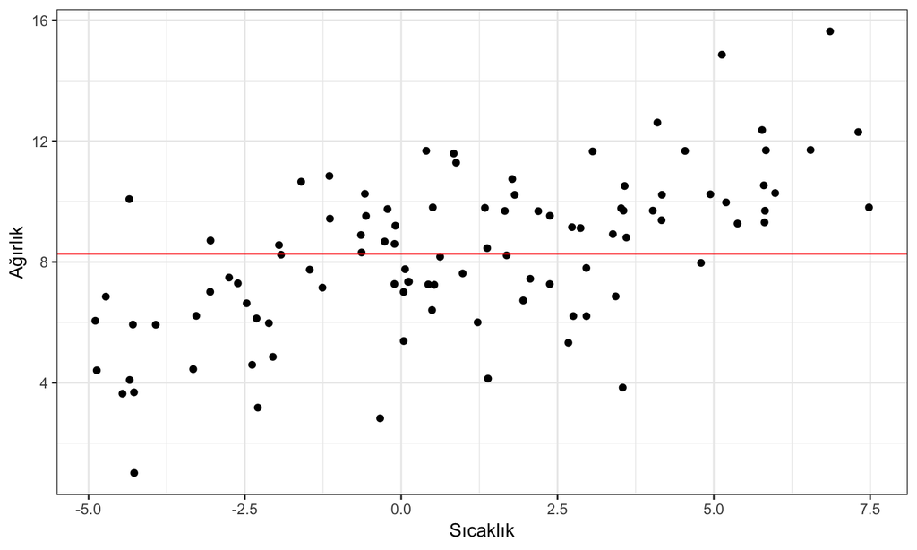

## Model Denetlemesi

### \(R^2\)

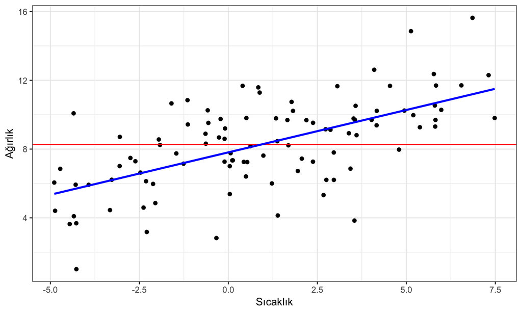

## Model Denetlemesi

### \(R^2\)

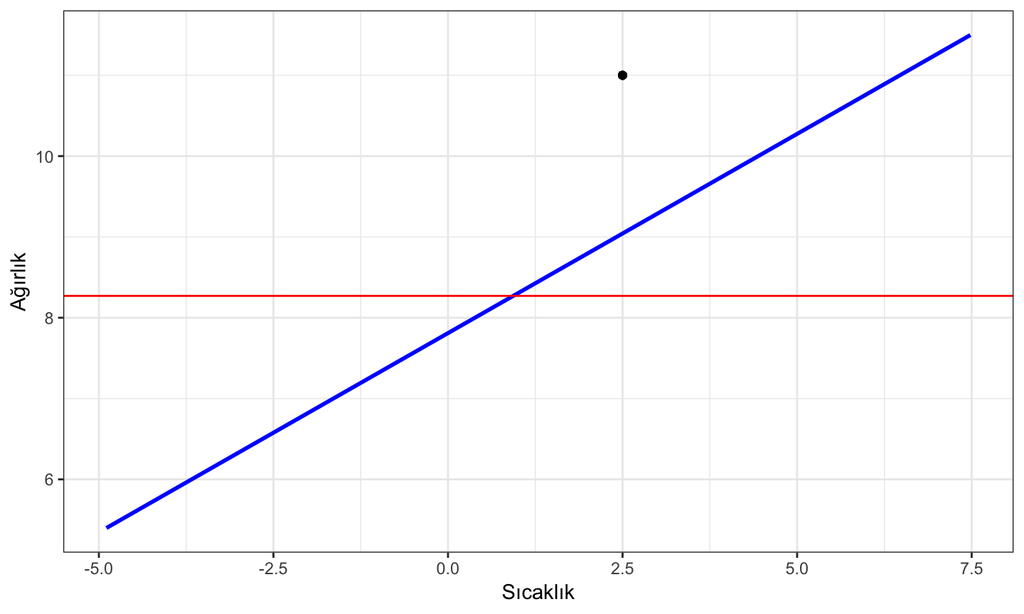

## Model Denetlemesi

### SST

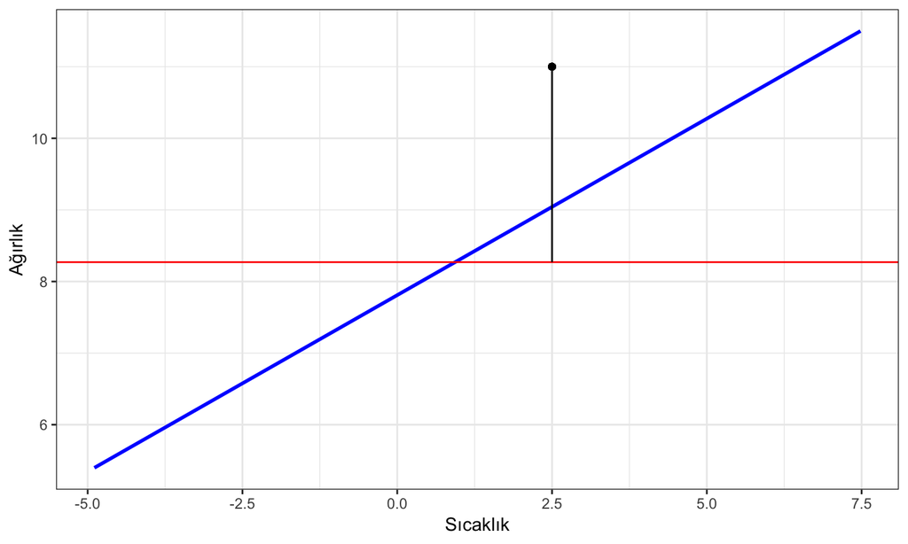

## Model Denetlemesi

### SSR

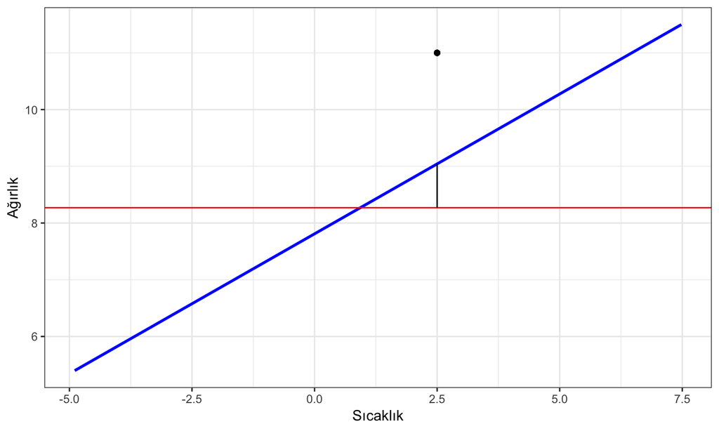

## Model Denetlemesi

### SSE

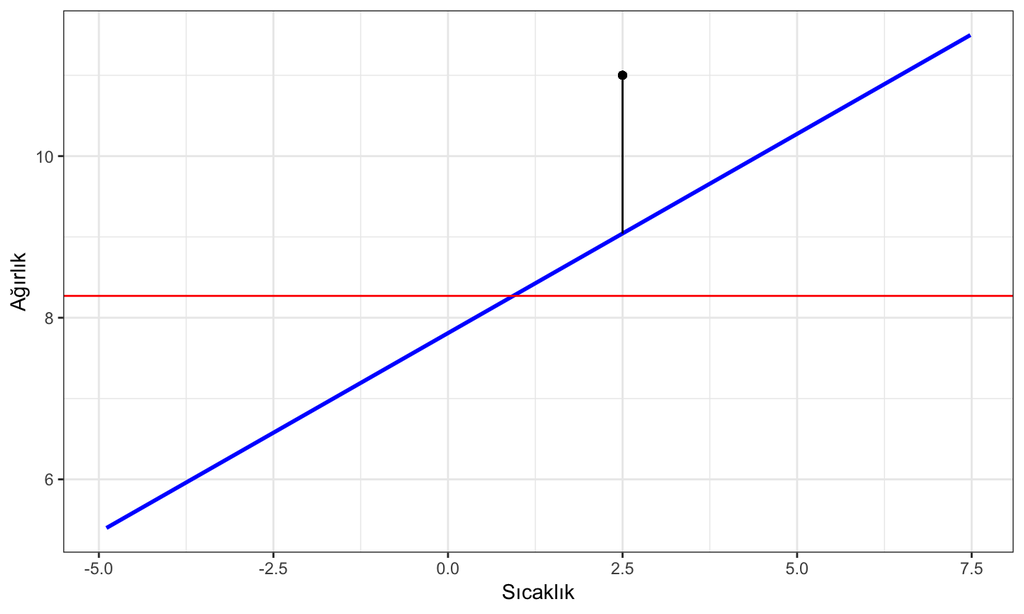

## Model Denetlemesi

### \(R^2\)

\[ SST = \sum{Y_i - \bar{Y}} \\ SSR = \sum{\hat{Y_i} - \bar{Y}} \\ SSE = \sum{Y_i - \hat{Y_i}} \]

## Model Denetlemesi

### \(R^2\)

\[ R^2=\frac{SSR}{SST}=\frac{1-SSE}{SST} \]

## Model Denetlemesi

### \(R^2\)

```r
summary(model1)
```

[output not shown]

## Model Denetlemesi

### \(R^2\)

```r
sum1 <- summary(model1)
sum1$r.squared
```

[output not shown]

```r
sum1$adj.r.squared
```

```
## [1] 0.3708649
```

## Model Denetlemesi

### Residual grafikleri

[figure not shown]

```r
plot(fitted(model1), residuals(model1), ylab = "Residuals", xlab = "Ağırlık")
```

## Veri normal dağılmıyorsa?

### Poisson

```r
alpha <- 5
beta <- 0.5
x <- rtruncnorm(100, mean = 0, sd = 5, a = -5, b = 8)
lambda <- exp(alpha + beta*x)
y <- rpois(100, lambda)
model2 <- lm(y ~ x)
```

## Veri normal dağılmıyorsa?

### Poisson

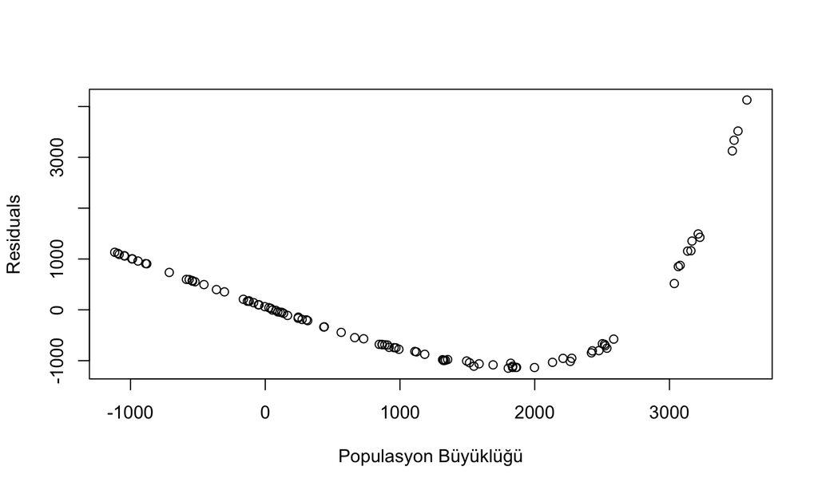

```r
plot(fitted(model2), residuals(model2), ylab = "Residuals", xlab = "Populasyon Büyüklüğü")
```

## Veri normal dağılmıyorsa?

### Poisson

```r
model3 <- glm(y ~ x, family = "poisson")
summary(model3)
```

```
##
## Call:
## glm(formula = y ~ x, family = "poisson")
##
## Deviance Residuals:
##     Min       1Q   Median       3Q      Max
## -2.6267  -0.6866   0.1264   0.8093   2.5527
##
## Coefficients:
##             Estimate Std. Error z value Pr(>|z|)
## (Intercept) 5.001850   0.009242   541.2   <2e-16 ***
## x           0.498982   0.001479   337.4   <2e-16 ***
## ---
## Signif. codes:  0 '***' 0.001 '**' 0.01 '*' 0.05 '.' 0.1 ' ' 1
##
## (Dispersion parameter for poisson family taken to be 1)
##
##     Null deviance: 202980.94  on 99  degrees of freedom
## Residual deviance:    131.81  on 98  degrees of freedom
## AIC: 857.32
##
## Number of Fisher Scoring iterations: 4
```

## Veri normal dağılmıyorsa?

### Poisson

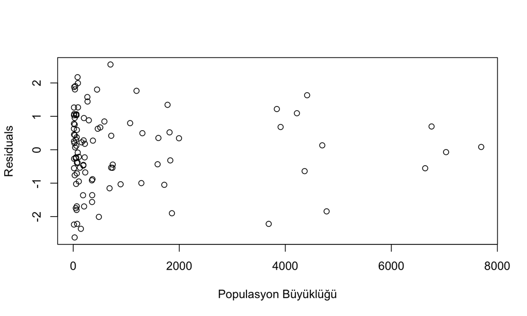

```r
plot(fitted(model3), residuals(model3), ylab = "Residuals", xlab = "Populasyon Büyüklüğü")
```

## R ve İstatistik

R'ı ve kod yazmayı bir istatistik paket programı(SPSS, MiniTab) gibi kullanmak zorunda değilsiniz. Kod yazmak kendi verinize ve uyguladığınız metodlara dair anlayışınız gelişmesine de çok büyük katkısı olacaktır.

## TEŞEKÜRLER!!

**Bilgecan**

- @bilgecan_sen ( [Twitter](https://twitter.com/bilgecan_sen) )
- bilgecansen ( [GitHub](https://github.com/bilgecansen) )